# PSY T880: HW 2

Tinashe Michael Tapera

24 January 2017

# Question 1

> 1. If the Bayes decision boundary is linear, do we expect LDA or QDA to perform better on the training set? On the test set?

QDA has greater flexibility, and so will fit more precisely to the training data. However, its quadratic nature would make it vary from the true linear boundary and so during the test stage LDA would perform better.

> 2. If the Bayes decision boundary is non-linear, do we expect LDA or QDA to perform better on the training set? On the test set?

LDA and QDA could perform similarly on the training set. It’s possible that LDA may outperform QDA if the sample is small. On the test set, QDA would definitely outperform LDA as the true boundary is non-linear.

> 3. In general, as the sample size n increases, do we expect the test prediction accuracy of QDA relative to LDA to improve, decline, or be unchanged? Why?

With a small sample, LDA would probably perform as well, if not better than, QDA. This is because few data points do not approximate a quadratic curve very well.

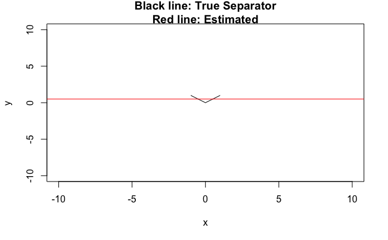

```r
x = seq(-1,1)
y = x^2
plot(x,y, xlim = c(-10,10), ylim = c(-10,10), type = "l", main = "Black line: True Separator\nRed line: Estimated")
abline(0.5,0, col = "red")
```

As you can see, a straight line can quite well capture all of the data. However, as one adds data points, the true nature of a curve is more distinct and so a non-linear line more accurately approximates the curve, meaning that a linear separator no longer applies, as below.

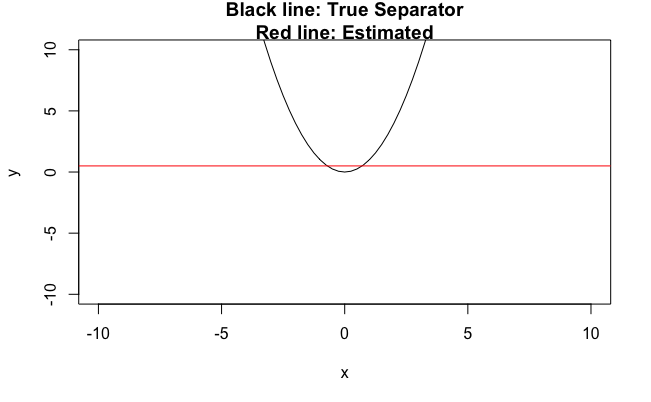

```r
x = seq(-5,5, 0.25)
y = x^2
plot(x,y, xlim = c(-10,10), ylim = c(-10,10), type = "l", main = "Black line: True Separator\nRed line: Estimated")
abline(0.5,0, col = "red")
```

> 4. True or False: Even if the Bayes decision boundary for a given problem is linear, we will probably achieve a superior test error rate using QDA rather than LDA because QDA is flexible enough to model a linear decision boundary. Justify your answer.

False. By nature of the quadratic curve, even if a separation boundary is linear for some small range of data (say, between -1 and 1 in the above graph), when the range is expanded ad infinitum, the boundary will rise or fall in a quadratic matter no matter how large or small the coefficients of the quadratic equation are.

$$f(x) = ax^2 + bx + c$$

No matter the size of a, b, and c, the curve will still be a curve that is concave or convex. So at some range to the left or right of the mean of our variable x, the data will fall out of this boundary.